< return to contents

# Reading GeoJSON files

Read a GeoJSON file, transform the coordinates and plot.

R packages

- [sf](https://cran.r-project.org/web/packages/sf/index.html)

Data

- [Countries of the UK](https://geoportal.statistics.gov.uk/datasets/countries-december-2020-uk-buc) (ONS Open Geography Portal)

Workflow

First we’ll load the [sf](https://cran.r-project.org/web/packages/sf/index.html) package.

```r
library(sf)
```

Then we’ll read the GeoJSON file by passing its URL to the [`st_read()`](https://r-spatial.github.io/sf/reference/st_read.html) function.

```r
sf <- st_read("https://opendata.arcgis.com/datasets/bb7104d3a9c04937be57e408288282dc_0.geojson")
```

```r
sf_bng <- st_transform(sf, crs = 27700)
```

To check that the data is projected in the right CRS we can inspect the CRS units. WGS84 uses decimal degrees (lat,long) whereas British National Grid uses metres.

```r
st_crs(sf)$units_gdal
```

```
## [1] "degree"
```

```r
st_crs(sf_bng)$units_gdal
```

```
## [1] "metre"
```

Finally, we’ll plot the data to see if it covers the area of interest.

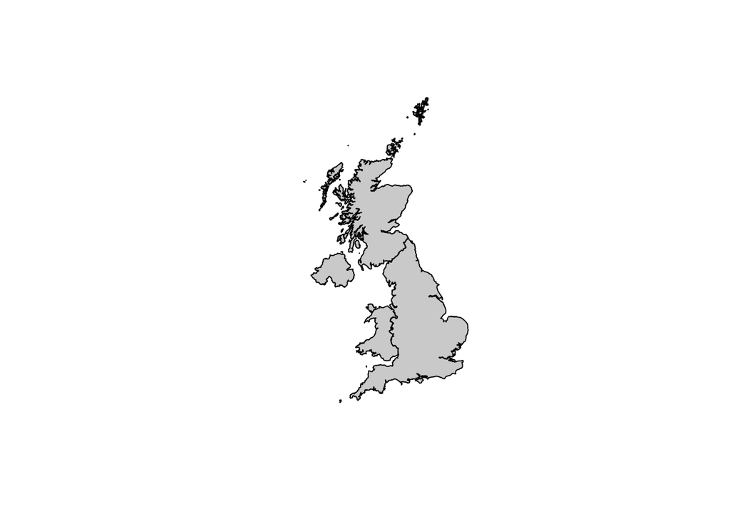

```r
plot(st_geometry(sf), col = "lightgrey")
```

Notes

When a coordinate reference system (CRS) is missing or wrongly set, the [`st_set_crs()`](https://r-spatial.github.io/sf/reference/st_crs.html) function can be used.